# Linked Cohort Analysis: Linking Case Records to Vaccination History

A complete starling workflow from preflight to vaccine effectiveness

Dr Nicolas Smoll, SCPHU, Sunshine Coast Hospital and Health Service

2026-11-24

```r
library(starling)
library(mudnester)   # clean_the_nest() and the clutch_* datasets
library(dplyr)
library(ggplot2)

aviary_cols <- c(satin = "#325D88", chestnut = "#86251C", wattle = "#D8A31A",
                 evergreen = "#08403B", mud = "#A67D4C", slate = "#3E3F3A")
```

## (*)> Overview

This vignette demonstrates the complete `starling` probabilistic record linkage workflow (Fellegi-Sunter scoring [3], run through `reclin2` [4]): pre-linkage audit, blocking, threshold sensitivity analysis, linkage, post-linkage validation, and the analysis the linkage exists to serve. The scenario mirrors a routine SCPHU task and the design of a regional Queensland linkage study of COVID-19 vaccine effectiveness [1]: link a notifiable-disease linelist to the Australian Immunisation Register (AIR) to establish COVID-19 vaccination status at onset, link the same linelist to hospital admissions to establish severity, and estimate vaccine effectiveness (VE) against hospitalisation.

The data are three of the `clutch` teaching datasets shipped in `mudnester`:

| Dataset | Rows | Role here |
| --- | --- | --- |
| `clutch_cases` | 3,182 | `data_x`: notified COVID-19, influenza, RSV and measles cases |
| `clutch_air` | 31,200 | `data_y` (vaccination): one row per vaccine encounter |
| `clutch_hospital` | 4,201 | `data_y` (hospitalisation): one row per episode of care |

All three are synthetic – no real person data – with the identifier errors real extracts carry (typos, nicknames, swapped day/month, missing and household-shared Medicare numbers). Every record also carries a `truth_id`, which real data never has. It is used here only to *grade* the linkage.

## (*)> Step 0: Clean both sides the same way

`mudnester::clean_the_nest()` standardises every source into the same schema. Roughly one notification in ten has no onset date, so the specimen date stands in for it first – `murmuration()` anchors every event window on `event_date`.

```r
cases_raw <- clutch_cases |>
  mutate(
    onset_imputed = is.na(onset_date),                  # keep a flag
    onset_date    = coalesce(onset_date, specimen_date) # fall back to the specimen date
  )

cases_clean <- clean_the_nest(
  cases_raw,
  data_type   = "cases",
  drop_eggs   = TRUE,
  id_var      = "notification_id",
  diagnosis   = "condition",
  lettername1 = "first_name",
  lettername2 = "surname",
  dob         = "date_of_birth",
  gender      = "sex",
  postcode    = "postcode",
  medicare    = "medicare_number",
  onset_date  = "onset_date",
  keep_vars   = c("truth_id", "onset_imputed")
)
```

> **(*)> One vaccine type at a time.** Filter the AIR extract to the vaccine you are studying before `clean_the_nest(lie_nest_flat = TRUE)` and `murmuration()`. Otherwise `vax_date_1`, `vax_date_2`, … interleave every vaccine the person has had – influenza, zoster, MMR – and the dose counts and `vaccination_status` mean “any vaccine”, not “a COVID-19 dose”. One vaccine per call is also how `murmuration()` is designed (`?murmuration`, “Linking one cohort to several event streams”).

```r
air_covid_raw <- clutch_air |>
  filter(antigen == "COVID-19")   # the one vaccine this analysis is about

air_covid <- clean_the_nest(
  air_covid_raw,
  data_type     = "vaccination",
  lie_nest_flat = TRUE,          # one row per person: vax_date_1, vax_type_1, ...
  drop_eggs     = TRUE,
  id_var        = "air_id",
  lettername1   = "given_name",
  lettername2   = "family_name",
  dob           = "date_of_birth",
  gender        = "sex",
  postcode      = "postcode",
  medicare      = "medicare_card",
  medicare_irn  = "medicare_irn",  # the AIR stores the IRN in its own column
  vax_type      = "antigen",
  vax_date      = "date_of_service",
  keep_vars     = "truth_id"
)

cases_clean |>
  count(diagnosis)
```

```
#>   diagnosis    n
#> 1  COVID-19 1400
#> 2 Influenza 1150
#> 3   Measles   12
#> 4       RSV  620
```

```r
c(covid_doses = nrow(air_covid_raw), people_with_a_covid_dose = nrow(air_covid))
```

```
#>              covid_doses people_with_a_covid_dose
#>                     8131                     4530
```

## (*)> Step 1: Pre-linkage audit with `preflight()`

Before generating a single candidate pair, `preflight()` checks completeness of the linkage variables, duplicate identifiers, date plausibility, Medicare validity, name quality and factor-level consistency across both datasets.

```r
cases_covid_clean <- cases_clean |>
  filter(diagnosis == "COVID-19")

audit <- preflight(
  data1        = cases_covid_clean,
  data2        = air_covid,
  linkage_vars = c("lettername1", "lettername2", "dob", "medicare10"),
  id_col1      = "id_var",
  id_col2      = "id_var",
  date_cols    = c("dob", "onset_date"),
  medicare_col = "medicare10",
  verbose      = FALSE
)

knitr::kable(audit$completeness, caption = "Completeness of the linkage variables")
```

Completeness of the linkage variables

| variable | dataset | n_records | n_present | n_missing | pct_missing |
| --- | --- | --- | --- | --- | --- |
| lettername1 | data1 | 1400 | 1395 | 5 | 0.4% |
| lettername2 | data1 | 1400 | 1400 | 0 | 0% |
| dob | data1 | 1400 | 1398 | 2 | 0.1% |
| medicare10 | data1 | 1400 | 1183 | 217 | 15.5% |
| lettername1 | data2 | 4530 | 4530 | 0 | 0% |
| lettername2 | data2 | 4530 | 4530 | 0 | 0% |
| dob | data2 | 4530 | 4530 | 0 | 0% |
| medicare10 | data2 | 4530 | 4489 | 41 | 0.9% |

```r
audit$flags
```

```
#> [1] "[MEDICARE] 53 failed checksum in data1"
```

The row to notice is Medicare: it is missing on 16% of COVID-19 notifications but almost never on the AIR. That single fact shapes the score distribution in Step 4.

## (*)> Step 2: Medicare checksum validation with `check_medicare()`

An invalid Medicare number that happens to resemble someone else’s adds spurious weight to a false pair. Setting it to `NA` is better: the EM algorithm treats `NA` as “not observed” and it contributes nothing, positive or negative.

```r
cases_checked <- cases_clean |>
  check_medicare(medicare_col = "medicare10", output_col = "medicare_valid",
                 verbose = FALSE) |>
  mutate(medicare10 = if_else(medicare_valid %in% 0L, NA_character_, medicare10))

air_checked <- air_covid |>
  check_medicare(medicare_col = "medicare10", output_col = "medicare_valid",
                 verbose = FALSE) |>
  mutate(medicare10 = if_else(medicare_valid %in% 0L, NA_character_, medicare10))

bind_rows(
  cases_checked |> mutate(dataset = "clutch_cases"),
  air_checked   |> mutate(dataset = "clutch_air (COVID-19)")
) |>
  group_by(dataset) |>
  summarise(
    valid          = sum(medicare_valid %in% 1L),
    fails_checksum = sum(medicare_valid %in% 0L),
    missing        = sum(is.na(medicare_valid))
  ) |>
  knitr::kable(caption = "Medicare numbers after check_medicare(): invalid ones are set to NA")
```

Medicare numbers after check_medicare(): invalid ones are set to NA

| dataset | valid | fails_checksum | missing |
| --- | --- | --- | --- |
| clutch_air (COVID-19) | 4489 | 0 | 41 |
| clutch_cases | 2578 | 113 | 491 |

## (*)> Step 3: Blocking variables with `flock()`

`murmuration()` only compares pairs that share a blocking key. Gender plus birth year keeps nearly every true pair together at a fraction of the cost of gender alone (see `vignette("pre-linkage-quality")` for the measured trade-off).

```r
cases_blocked <- flock(cases_checked,
                       block1_vars    = c("gender", "birth_year"),
                       birth_year_col = "dob")
air_blocked   <- flock(air_checked,
                       block1_vars    = c("gender", "birth_year"),
                       birth_year_col = "dob")

cases_covid <- cases_blocked |>
  filter(diagnosis == "COVID-19")

c(covid_cases = nrow(cases_covid),
  air_people  = nrow(air_blocked),
  strata      = length(intersect(cases_covid$block1, air_blocked$block1)))
```

```
#> covid_cases  air_people      strata
#>        1400        4530         196
```

## (*)> Step 4: Look at the scores before trusting a threshold

The first run leaves `threshold_value` at the starling default of 16 and keeps the full candidate-pairs table (`keep_pairs_pred = TRUE`) so it can be inspected. The vaccination window counts a COVID-19 dose as current if it was given 14–182 days before onset.

```r
linked_16 <- murmuration(
  data_x          = cases_covid,     # one row per COVID-19 case
  data_y          = air_blocked,     # one row per AIR person, COVID-19 doses only
  linkage_type    = "cohort2event",  # a cohort linked to an event stream...
  event_type      = "vaccination",   # ...of vaccinations
  event_date      = "onset_date",    # each case's own anchor date
  id_var          = "id_var",        # the case identifier, kept on every row
  blocking_var    = "block1",        # only pairs of the same gender and birth year
  compare_vars    = c("lettername1", "lettername2", "dob", "medicare10"),
  # threshold_value not set: the default, 16
  vax_window      = list(days_before = 14, days_after = 0, lookback_days = 182),
  keep_pairs_pred = TRUE             # keep every scored pair for the plots
)
```

`perch()` sweeps candidate thresholds over the scored pairs without re-fitting anything. With `plot = FALSE` it returns its table invisibly:

```r
pp_16 <- attr(linked_16, "pairs_pred") |>
  as.data.frame()

# the most a pair can score when Medicare is missing on one side
max_weight_no_medicare <- pp_16 |>
  filter(is.na(medicare10)) |>
  pull(weights) |>
  max()

sweep <- perch(pp_16,
               n_records_primary = nrow(cases_covid),
               thresholds        = seq(4, 20, by = 1),
               report            = FALSE,
               plot              = FALSE)

knitr::kable(sweep[, c("threshold", "n_above", "n_clerical", "link_rate", "reference")],
             caption = "Accepted pairs and clerical burden at each candidate threshold")
```

Accepted pairs and clerical burden at each candidate threshold

| threshold | n_above | n_clerical | link_rate | reference |
| --- | --- | --- | --- | --- |
| 4 | 2131 | 21568 | 1.5221 | NA |
| 5 | 1667 | 6796 | 1.1907 | NA |
| 6 | 991 | 1925 | 0.7079 | NA |
| 7 | 803 | 1373 | 0.5736 | NA |
| 8 | 795 | 1055 | 0.5679 | NA |
| 9 | 783 | 389 | 0.5593 | NA |
| 10 | 758 | 203 | 0.5414 | AIHW/WADLU: lower bound of clerical review zone |
| 11 | 612 | 290 | 0.4371 | NA |
| 12 | 602 | 280 | 0.4300 | NA |
| 13 | 600 | 256 | 0.4286 | NA |
| 14 | 505 | 125 | 0.3607 | NA |
| 15 | 503 | 152 | 0.3593 | PHRN: lower bound for <0.5% false-match rate (full variable set) |
| 16 | 502 | 175 | 0.3586 | starling default (balanced: Medicare + 2 names + DOB) |
| 17 | 487 | 505 | 0.3479 | NA |
| 18 | 450 | 503 | 0.3214 | NA |
| 19 | 425 | 502 | 0.3036 | NA |
| 20 | 0 | 487 | 0.0000 | AIHW/WADLU: upper bound of clerical zone / confirmed matches above |

The count of accepted pairs barely moves between about 7 and 10, then falls away in steps above 10. The first step is the Medicare effect: a true pair whose Medicare number is missing on one side can score at most the name and date-of-birth weights, which here sum to about 10.6. At 16 every one of those true pairs is thrown away, and so is every true pair whose card was reissued between the two records (a different tenth digit; see `vignette("threshold-selection")`, which measures both).

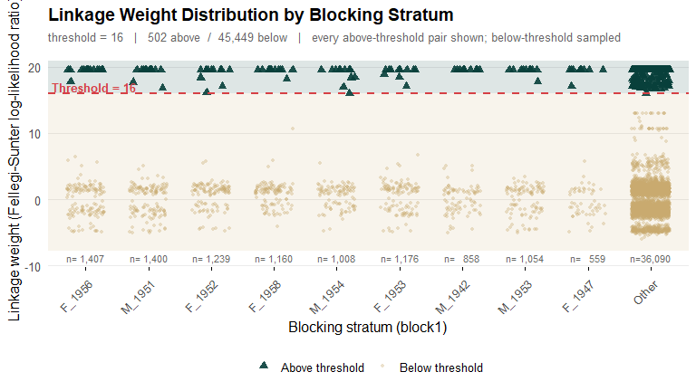

Candidate-pair weights at the default threshold of 16. The upper cluster (all four fields agree) sits above 16; the true matches with a reissued card or no Medicare number on one side sit between about 10 and 13, entirely below the line.

```r
murmuration_plot(linked_16, max_levels = 10)
```

The valley between the non-match cloud and the lower match cluster sits near 8, so the linkage is re-run there – the same look-before-fixing discipline an infant immunisation coverage study applied to its birth-register matching [2]. The starling default and the AIHW/WADLU and PHRN benchmarks in the `perch()` table all assume a five-variable key with a Medicare number present and current on both sides; with four variables and frequent Medicare gaps the scale is simply lower.

| Range | Source | Meaning |
| --- | --- | --- |
| 10–20 | AIHW / WA Data Linkage Unit | Clerical review zone |
| 15–20 | PHRN | Operational target for <0.5% false-match rate (full variable set) |
| 16 | starling default | Calibrated for 5 comparison variables with an agreeing Medicare number |

## (*)> Step 5: Probabilistic linkage with `murmuration()`

```r
linked_cov <- murmuration(
  data_x          = cases_covid,     # one row per COVID-19 case
  data_y          = air_blocked,     # one row per AIR person, COVID-19 doses only
  linkage_type    = "cohort2event",
  event_type      = "vaccination",
  event_date      = "onset_date",    # the window is measured back from onset
  id_var          = "id_var",
  blocking_var    = "block1",        # gender + birth year
  compare_vars    = c("lettername1", "lettername2", "dob", "medicare10"),
  threshold_value = 8,               # the valley seen in Step 4
  vax_window      = list(days_before = 14,     # a dose counts from 14 days old...
                         days_after = 0,
                         lookback_days = 182), # ...until 182 days old
  suffix          = "_cov",          # tag every column this call adds
  keep_pairs_pred = TRUE
)

bind_rows(
  linked_16  |> summarise(threshold     = 16,
                          linked_to_air = sum(!is.na(id_var_y)),
                          current_dose  = sum(vaccination_status == "Vaccinated")),
  linked_cov |> summarise(threshold     = 8,
                          linked_to_air = sum(!is.na(id_var_y_cov)),
                          current_dose  = sum(vaccination_status_cov == "Vaccinated"))
) |>
  knitr::kable(caption = "COVID-19 cases linked to an AIR record, and with a dose 14-182 days before onset")
```

COVID-19 cases linked to an AIR record, and with a dose 14-182 days before onset

| threshold | linked_to_air | current_dose |
| --- | --- | --- |
| 16 | 502 | 119 |
| 8 | 777 | 194 |

`suffix = "_cov"` tags every column this call contributed (`weights_cov`, `id_var_y_cov`, `vaccination_status_cov`, `vax_date_1_cov`, …) while the case columns, including `id_var`, stay plain – so the result can be joined to the hospital linkage in Step 8 without collisions. The vaccination route returns an ordinary, ungrouped data frame with one row per case. Alongside the in-window `vax_date_*`/`vax_type_*` columns it adds:

| Column | Meaning |
| --- | --- |
| `vaccination_status` | `"Vaccinated"` if any dose falls inside `vax_window`, otherwise `"Unvaccinated"` (including cases with no AIR record) |
| `vaccination_status_num` | The same as 1/0, ready for a model |
| `total_valid_vax` | Number of in-window doses |
| `first_vax_date`, `last_vax_date` (and `_type`) | Earliest and latest in-window dose |
| `tsv` | Days from the last in-window dose to `event_date`; 0 when unvaccinated |

“Vaccinated” below means `vaccination_status_cov == "Vaccinated"`.

```r
linked_cov |>
  count(vaccination_status_cov, total_valid_vax_cov, name = "cases") |>
  knitr::kable(caption = "vaccination_status against the number of in-window doses (threshold 8)")
```

vaccination_status against the number of in-window doses (threshold 8)

| vaccination_status_cov | total_valid_vax_cov | cases |
| --- | --- | --- |
| Unvaccinated | 0 | 1206 |
| Vaccinated | 1 | 188 |
| Vaccinated | 2 | 6 |

## (*)> Step 6: Visualise the final score distribution

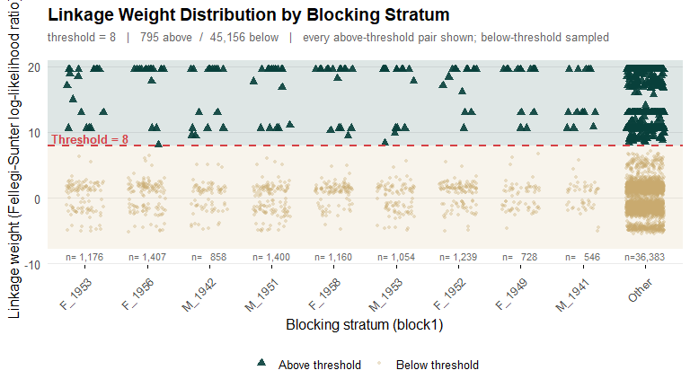

Linkage weight distribution at threshold 8, jittered by blocking stratum (gender + birth year). Above-threshold pairs are drawn as triangles.

```r
murmuration_plot(linked_cov, max_levels = 10, palette = "sch")
```

If the distribution is cleanly bimodal and the above-threshold count matches expectations, this is normally as far as you need to go. If specific borderline pairs deserve a human judgement, see `vignette("clinical-linkage-review")` for `inspect_matches` and `resume_from_pairs`.

## (*)> Step 7: Post-linkage validation against the truth

In production this step needs a clerical review sample. Here the matched AIR record’s `truth_id` can be compared with the case’s directly.

```r
# the truth_id behind each matched AIR record -- used only to grade the links
air_truth <- air_blocked |>
  select(id_var_y_cov = id_var, truth_id_air = truth_id)

grading <- linked_cov |>
  left_join(air_truth, by = "id_var_y_cov") |>
  summarise(
    n_links   = sum(!is.na(id_var_y_cov)),
    n_correct = sum(truth_id == truth_id_air, na.rm = TRUE)
  )
n_links   <- grading$n_links
n_correct <- grading$n_correct
n_true    <- cases_covid |>
  filter(truth_id %in% air_blocked$truth_id) |>
  nrow()

tibble(
  measure = c("Accepted links", "Correct links", "Cases with a true AIR record",
              "Precision (%)", "Recall (%)"),
  value   = c(n_links, n_correct, n_true,
              round(100 * n_correct / n_links, 1),
              round(100 * n_correct / n_true, 1))
) |>
  knitr::kable()
```

| measure | value |
| --- | --- |
| Accepted links | 777.0 |
| Correct links | 769.0 |
| Cases with a true AIR record | 796.0 |
| Precision (%) | 99.0 |
| Recall (%) | 96.6 |

### A note on cases with more than one candidate

```r
# every candidate pair above the threshold, with both sides' truth_id
above <- attr(linked_cov, "pairs_pred") |>
  as.data.frame() |>
  filter(weights >= 8) |>
  select(row_x = .x, row_y = .y, weights) |>
  mutate(truth_x = cases_covid$truth_id[row_x],
         truth_y = air_blocked$truth_id[row_y])

# cases with two or more candidates
multi_x <- above |>
  count(row_x) |>
  filter(n > 1) |>
  pull(row_x)

# what murmuration() keeps: the highest-weighted candidate per case
best <- above |>
  arrange(desc(weights)) |>
  distinct(row_x, .keep_all = TRUE)

best_multi <- best |>
  filter(row_x %in% multi_x)

tibble(
  measure = c("Cases with 2+ candidates above 8",
              "  of which the highest-weighted candidate is the right person",
              "Precision of murmuration()'s links (%)",
              "Precision recomputed from the pairs, highest weight per case (%)"),
  value   = c(length(multi_x),
              sum(best_multi$truth_x == best_multi$truth_y),
              round(100 * n_correct / n_links, 1),
              round(100 * mean(best$truth_x == best$truth_y), 1))
) |>
  knitr::kable()
```

| measure | value |
| --- | --- |
| Cases with 2+ candidates above 8 | 18 |
| of which the highest-weighted candidate is the right person | 18 |
| Precision of murmuration()’s links (%) | 99 |
| Precision recomputed from the pairs, highest weight per case (%) | 99 |

## (*)> Step 8: Linking the same cases to hospital admissions

The hospital extract codes sex as `"Male"`/`"Female"`, so it is recoded before cleaning (otherwise no pair would ever share a block). Only acute episodes are relevant; maternity and newborn episodes are left out. An admission counts as disease-related if it starts between 7 days before and 14 days after onset, and a death within 30 days of onset counts as a COVID-19 death.

```r
hosp_raw <- clutch_hospital |>
  filter(care_type == "Acute") |>                      # no maternity or newborn episodes
  mutate(sex = case_when(sex == "Male"   ~ "M",        # the hospital codes sex in full;
                         sex == "Female" ~ "F"))       # every other source uses M/F

hosp_clean <- clean_the_nest(
  hosp_raw,
  data_type      = "hospital",
  drop_eggs      = TRUE,
  id_var         = "ur_number",
  event_id_var   = "episode_id",
  lettername1    = "given_name",
  lettername2    = "family_name",
  dob            = "birth_date",
  gender         = "sex",
  postcode       = "postcode",
  medicare       = "medicare_no",
  admission_date = "admit_date",
  discharge_date = "separation_date",
  hospital       = "facility",
  icd_code       = "principal_diagnosis",
  drg            = "drg",
  icu_date       = "icu_date",
  icu_hours      = "icu_hours",
  dod            = "death_date",   # age at admission is derived from dob and admit_date
  keep_vars      = c("truth_id", "diagnosis_codes")
)

hosp_blocked <- hosp_clean |>
  check_medicare(medicare_col = "medicare10", output_col = "medicare_valid",
                 verbose = FALSE) |>
  mutate(medicare10 = if_else(medicare_valid %in% 0L, NA_character_, medicare10)) |>
  flock(block1_vars    = c("gender", "birth_year"),
        birth_year_col = "dob")
```

```r
linked_hosp <- murmuration(
  data_x                    = cases_blocked,      # every case, all four conditions
  data_y                    = hosp_blocked,       # acute episodes
  linkage_type              = "cohort2event",
  event_type                = "hospitalisation",
  event_date                = "onset_date",
  id_var                    = "id_var",
  blocking_var              = "block1",           # gender + birth year
  compare_vars              = c("lettername1", "lettername2", "dob", "medicare10"),
  threshold_value           = 8,
  days_allowed_before_event = 7,                  # admitted up to 7 days before onset...
  days_allowed_after_event  = 14,                 # ...or up to 14 days after
  days_between_onset_death  = 30,                 # a death within 30 days of onset
  suffix                    = "_hosp",
  keep_pairs_pred           = TRUE
)

linked_hosp |>
  summarise(cases              = n(),
            linked_to_hospital = sum(!is.na(id_var_y_hosp)),
            admitted_in_window = sum(admission_outcome_hosp == "Admission")) |>
  knitr::kable(caption = "Cases linked to an acute hospital record, and admitted in the window")
```

Cases linked to an acute hospital record, and admitted in the window

| cases | linked_to_hospital | admitted_in_window |
| --- | --- | --- |
| 3182 | 319 | 319 |

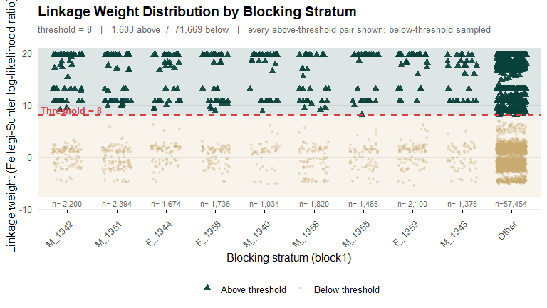

Case-to-hospital candidate-pair weights at threshold 8.

```r
murmuration_plot(linked_hosp, max_levels = 10)
```

## (*)> Step 9: Case-hospitalisation, ICU and case-fatality

The hospitalisation route adds `admission_outcome`, `first_admission_date`, `icu_outcome` and `death_outcome` (here suffixed `_hosp`). Columns that come only from the hospital extract (`diagnosis_codes_hosp` here) are blank for a case whose matched admission falls outside the window, so they always describe the in-window admission. The truth column repeats the same window rule using `truth_id`, so the two can be compared.

```r
# the truth: an acute admission of the same person within the same window
truth_adm <- cases_blocked |>
  select(id_var, truth_id, onset_date) |>
  inner_join(hosp_clean |> select(truth_id, admission_date),
             by = "truth_id", relationship = "many-to-many") |>
  filter(admission_date >= onset_date - 7,
         admission_date <= onset_date + 14)

linked_hosp <- linked_hosp |>
  mutate(admitted       = admission_outcome_hosp == "Admission",
         icu            = icu_outcome_hosp == "ICU Admission",
         died           = death_outcome_hosp == "Died",
         admitted_truth = id_var %in% truth_adm$id_var)

severity <- linked_hosp |>
  group_by(condition = diagnosis) |>
  summarise(cases          = n(),
            admitted       = sum(admitted),
            admitted_truth = sum(admitted_truth),
            icu            = sum(icu, na.rm = TRUE),
            died_30d       = sum(died, na.rm = TRUE)) |>
  mutate(chr_pct       = round(100 * admitted / cases, 1),
         chr_truth_pct = round(100 * admitted_truth / cases, 1),
         cfr_pct       = round(100 * died_30d / cases, 2))

knitr::kable(severity, caption = "Case-hospitalisation (CHR) and case-fatality (CFR) by condition, linked vs truth")
```

Case-hospitalisation (CHR) and case-fatality (CFR) by condition, linked vs truth

| condition | cases | admitted | admitted_truth | icu | died_30d | chr_pct | chr_truth_pct | cfr_pct |
| --- | --- | --- | --- | --- | --- | --- | --- | --- |
| COVID-19 | 1400 | 123 | 125 | 19 | 18 | 8.8 | 8.9 | 1.29 |
| Influenza | 1150 | 87 | 92 | 6 | 8 | 7.6 | 8.0 | 0.70 |
| Measles | 12 | 5 | 5 | 0 | 0 | 41.7 | 41.7 | 0.00 |
| RSV | 620 | 104 | 108 | 20 | 9 | 16.8 | 17.4 | 1.45 |

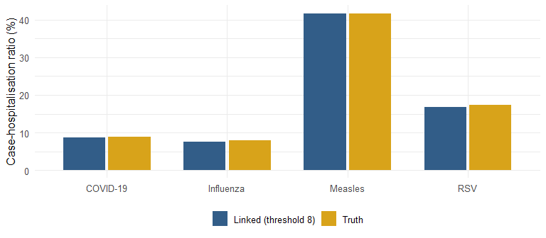

```r
chr_long <- bind_rows(
  severity |> transmute(condition, source = "Linked (threshold 8)", chr = chr_pct),
  severity |> transmute(condition, source = "Truth",                chr = chr_truth_pct)
)

ggplot(chr_long, aes(x = condition, y = chr, fill = source)) +
  geom_col(position = position_dodge(width = 0.75), width = 0.7) +
  scale_fill_manual(values = c("Linked (threshold 8)" = aviary_cols[["satin"]],
                               "Truth" = aviary_cols[["wattle"]])) +
  labs(x = NULL, y = "Case-hospitalisation ratio (%)", fill = NULL) +
  theme_minimal(base_size = 12) +
  theme(legend.position = "bottom")
```

```r
n_died_after_discharge <- linked_hosp |>
  filter(died, dod_hosp > first_discharge_date_hosp) |>
  nrow()

pct_covid_coded <- linked_hosp |>
  filter(admitted, diagnosis == "COVID-19") |>
  summarise(pct = round(100 * mean(grepl("U07[.]1|B97[.]2", diagnosis_codes_hosp)))) |>
  pull(pct)
```

Two details worth knowing:

- Deaths are recorded on the hospital episode, and 14 of the linked 30-day deaths happened *after* discharge. `death_outcome` measures from onset, not from separation, so they are still counted.
- The window rule counts any acute admission that starts near onset. Of the linked COVID-19 admissions, 75% carry a COVID-19 code (U07.1 or B97.2) anywhere on the episode. The published study required B97.2 as an additional diagnosis [1]; filter on `diagnosis_codes` before linking if your definition needs it.

## (*)> Step 10: Vaccine effectiveness against hospitalisation

Both linkages hang off the same `id_var`, so they join directly. Among COVID-19 cases, VE against hospitalisation is estimated as one minus the risk ratio of admission, vaccinated versus not, from a log-link Poisson model with robust (sandwich) standard errors – the modified Poisson approach [5], which estimates the same risk ratio as the log-binomial model of the published study [1] but always converges.

```r
covid <- linked_hosp |>
  filter(diagnosis == "COVID-19") |>
  select(id_var, truth_id, age, onset_date, admitted, admitted_truth) |>
  inner_join(linked_cov |> select(id_var, vaccination_status_cov), by = "id_var") |>
  mutate(vaccinated   = vaccination_status_cov == "Vaccinated",
         hospitalised = as.integer(admitted),
         age_group    = cut(age, c(-Inf, 50, 65, 80, Inf), right = FALSE,
                            labels = c("<50", "50-64", "65-79", "80+")))

# The same exposure from the truth: a COVID-19 dose 14-182 days before onset
vaccinated_truth_ids <- covid |>
  select(id_var, truth_id, onset_date) |>
  inner_join(clutch_air |>
               filter(antigen == "COVID-19") |>
               select(truth_id, date_of_service),
             by = "truth_id", relationship = "many-to-many") |>
  mutate(days_since_dose = as.numeric(onset_date - date_of_service)) |>
  filter(days_since_dose >= 14, days_since_dose <= 182) |>
  pull(id_var)

covid <- covid |>
  mutate(vaccinated_truth   = id_var %in% vaccinated_truth_ids,
         hospitalised_truth = as.integer(admitted_truth))

covid |>
  mutate(vaccination = if_else(vaccinated, "Vaccinated", "Unvaccinated"),
         admission   = if_else(hospitalised == 1, "admitted", "not admitted")) |>
  count(age_group, vaccination, admission, name = "cases") |>
  knitr::kable(caption = "COVID-19 cases by age group, vaccination status and admission (linked data)")
```

COVID-19 cases by age group, vaccination status and admission (linked data)

| age_group | vaccination | admission | cases |
| --- | --- | --- | --- |
| <50 | Unvaccinated | admitted | 9 |
| <50 | Unvaccinated | not admitted | 449 |
| <50 | Vaccinated | not admitted | 7 |
| 50-64 | Unvaccinated | admitted | 11 |
| 50-64 | Unvaccinated | not admitted | 218 |
| 50-64 | Vaccinated | not admitted | 26 |
| 65-79 | Unvaccinated | admitted | 46 |
| 65-79 | Unvaccinated | not admitted | 286 |
| 65-79 | Vaccinated | admitted | 6 |
| 65-79 | Vaccinated | not admitted | 80 |
| 80+ | Unvaccinated | admitted | 43 |
| 80+ | Unvaccinated | not admitted | 142 |
| 80+ | Vaccinated | admitted | 8 |
| 80+ | Vaccinated | not admitted | 67 |
| NA | Unvaccinated | not admitted | 2 |

Vaccinated cases are concentrated in the oldest age groups, where admission is most common, so the crude comparison understates protection. Age adjustment matters here:

```r
ve_fits <- list(
  "Crude (linked)"        = glm(hospitalised ~ vaccinated,
                                family = poisson(link = "log"), data = covid),
  "Age-adjusted (linked)" = glm(hospitalised ~ vaccinated + age_group,
                                family = poisson(link = "log"), data = covid),
  "Age-adjusted (truth)"  = glm(hospitalised_truth ~ vaccinated_truth + age_group,
                                family = poisson(link = "log"), data = covid)
)

ve_rows <- list()
for (model_name in names(ve_fits)) {
  fit   <- ve_fits[[model_name]]
  X     <- model.matrix(fit)
  bread <- summary(fit)$cov.unscaled
  meat  <- crossprod(X * (fit$y - fitted(fit)))
  se    <- sqrt(diag(bread %*% meat %*% bread))[2]   # robust SE, vaccination term
  b     <- coef(fit)[2]
  ve_rows[[model_name]] <- tibble(
    model = model_name,
    VE    = round(100 * (1 - exp(b)), 1),
    lower = round(100 * (1 - exp(b + 1.96 * se)), 1),
    upper = round(100 * (1 - exp(b - 1.96 * se)), 1)
  )
}
ve_table <- bind_rows(ve_rows)

knitr::kable(ve_table, caption = "VE (%) against hospitalisation among COVID-19 cases, 95% CI (robust)")
```

VE (%) against hospitalisation among COVID-19 cases, 95% CI (robust)

| model | VE | lower | upper |
| --- | --- | --- | --- |
| Crude (linked) | 20.2 | -36.4 | 53.3 |
| Age-adjusted (linked) | 54.6 | 22.8 | 73.3 |
| Age-adjusted (truth) | 56.7 | 26.4 | 74.5 |

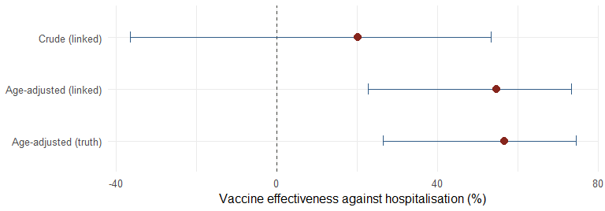

```r
ve_table |>
  mutate(model = factor(model, levels = rev(model))) |>
  ggplot(aes(x = VE, y = model)) +
  geom_vline(xintercept = 0, colour = aviary_cols[["slate"]], linetype = "dashed") +
  geom_errorbar(aes(xmin = lower, xmax = upper), width = 0.2, orientation = "y",
                colour = aviary_cols[["satin"]]) +
  geom_point(size = 3, colour = aviary_cols[["chestnut"]]) +
  labs(x = "Vaccine effectiveness against hospitalisation (%)", y = NULL) +
  theme_minimal(base_size = 12)
```

The age-adjusted estimate from the linked data (54.6%, 95% CI 22.8 to 73.3) sits close to the estimate from perfect linkage (56.7%), so linkage error at this threshold barely moves the answer. For comparison, the published regional Queensland study reported 69.9% (44.3–83.8) for a primary course and 81.8% (39.5–94.5) with a booster, adjusting for age (<50/≥50), sex and Indigenous status [1]. The synthetic world was generated with a weaker effect; the point here is the workflow, not the number.

## (*)> Summary: the complete starling workflow

```r
library(starling)
library(mudnester)
library(dplyr)

# 0. Clean every source the same way -- and the AIR for ONE vaccine type only
cases <- clutch_cases |>
  mutate(onset_date = coalesce(onset_date, specimen_date)) |>
  clean_the_nest(data_type = "cases", id_var = "notification_id", ...)
air <- clutch_air |>
  filter(antigen == "COVID-19") |>
  clean_the_nest(data_type = "vaccination", lie_nest_flat = TRUE,
                 medicare = "medicare_card", medicare_irn = "medicare_irn", ...)
hosp <- clutch_hospital |>
  mutate(sex = case_when(sex == "Male" ~ "M", sex == "Female" ~ "F")) |>
  clean_the_nest(data_type = "hospital", ...)

# 1-3. Audit, Medicare validation (invalid -> NA), blocking
preflight(cases, air, linkage_vars = c("lettername1", "lettername2", "dob", "medicare10"))
cases <- cases |>
  check_medicare() |>
  mutate(medicare10 = if_else(medicare_valid %in% 0L, NA_character_, medicare10)) |>
  flock(block1_vars = c("gender", "birth_year"), birth_year_col = "dob")

# 4. Look before trusting a threshold (threshold_value defaults to 16)
first_pass <- murmuration(data_x = cases, data_y = air,
  linkage_type = "cohort2event", event_type = "vaccination",
  event_date = "onset_date", id_var = "id_var", blocking_var = "block1",
  compare_vars = c("lettername1", "lettername2", "dob", "medicare10"),
  keep_pairs_pred = TRUE)
perch(attr(first_pass, "pairs_pred"), n_records_primary = nrow(cases))
murmuration_plot(first_pass)

# 5-7. Link at the chosen threshold, one call per event stream, then validate
vax <- murmuration(data_x = cases, data_y = air, ..., threshold_value = 8,
  suffix = "_cov",
  vax_window = list(days_before = 14, days_after = 0, lookback_days = 182))
adm <- murmuration(data_x = cases, data_y = hosp, linkage_type = "cohort2event",
  event_type = "hospitalisation", ..., threshold_value = 8, suffix = "_hosp")

# 8-10. Join on id_var and analyse
cohort <- adm |>
  inner_join(vax |> select(id_var, vaccination_status_cov), by = "id_var")
```